# RatingsStatPlot

## The Beginning

After looking through an exhausting amountof public datasets I finally stumbled upon a set of nearly all IGN's game ratings at https://www.dropbox.com/s/09sh15zbtwg9eu3/gamedata.xlsx. Not only was this a of a more managable size than every near-earth asteroid in the solar system (hint: theres alot) but I know something about IGN ratings. I wondered: how do IGN ratings compare to that of another site, such as Metacritic? Now, I had a starting point!

I set to learning Python in order to create a web scraper to get metacritic scores for the IGN games I had. After several hours, I (and many more of formatting) I completed my scraper. You can find the code for it here: https://github.com/wraley/PythonScraper

My scraper did its job and found metacritic scores for a significant portion of my database. Sadly, Metacritic does not have quite as extensive a database as IGN so our new dataset is much smaller. The next step is to clean up some of our results.

## Cleaning up

We'll use the pandas module for manipulating out data, and matplotlib for visualizing the data in some neat boxplots.

The first step is to start cleaning the results from my metacritic scraper. Unfortunately, due to the nature of my code the are far from beautiful. Xlrd gives uses commas to break up cells, and so game titles with commas got butchered. Some other character combinations or other errors resulted in a designated 'failed' status. Lastly, metacritic does not have as extensive a game database as IGN so many of the games did not have a rating. We'll need to remove any rows that fit this criteria.

```python
from matplotlib import pyplot as plt
import pandas as pd
plt.style.use('ggplot')
import numpy as np

df = pd.read_csv('E:\Data Libraries\Billy\coding\metacriticScraper\Final_Data.csv')

# Remove any rows where scraper failed to obtain score, or where Metacritic did not have a rating
df = df.drop(df[df.Meta_Rating == 'failed'].index)
df = df.drop(df[df.Meta_Rating == 'None'].index)
```

## Polishing off

Now that we've removed our trouble rows, we can go about fixing our data types. As I said before, some of the rows got butchered, meaning there were strings in ratings columns. We've successfully dealt with this so we can set about casting our columns into their proper datatypes for manipulation later on. Last but not least, we'll scale the IGN Ratings by 10 so that its on the same scale as Metacritic.

```python
# Now that all the columns agree, we can cast the ratings columns to floats
df['IGN_Rating'] = df['IGN_Rating'].astype('float64')
df['Meta_Rating'] = df['Meta_Rating'].astype('float64')

# IGN rates from 0-10 and Metacritic rates from 0-100 so lets multiply IGN by 10 for simplicity
df['IGN_Rating'] *= 10
```

# Data Analysis

The dataset is finally clean and tidy, so now we can get to work analyzing the results of our efforts. Pandas has a handy method: describe(). We can jump right into comparing the statistical results of the dataset!

```python
print(df.describe())
```

```
        IGN_Rating  Meta_Rating
count  8751.000000  8751.000000
mean     70.887784    69.224431
std      16.373944    13.940056
min      10.000000    16.000000
25%      60.000000    61.000000
50%      75.000000    71.000000
75%      84.000000    80.000000
max     100.000000    99.000000
```

### Stats

Coming into this project, I expected to find a large disparity between my two datasets. I regularly read IGN reviews, and pay attention to their ratings. Many games, particularly AAA titles like Call of Duty rarely get below a 90-95 despite fans feeling otherwise. I've also heard stories basing many of their financial decisions on metacritic ratings. As a result, I expected to find IGN ratings skewed towards the left, and Metacritic to have a more even distribution.

As it turns out, my assumptions were quite wrong. The means, standard deviation. as well as our 3 intervals we all within 4 points of each other. It seems that the game ratings community is suprisingly consistent.

The matplotlib module also has some handy visualization methods that help show just how consistent these two sites are. Both are skewed right of a perfect bell curve, but I suppose that means people have been making some pretty good games. Alternatively, (and more likely) IGN and Metacritic dont have reviews for games that are complete shit.

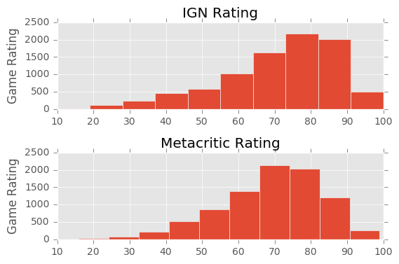

```python
fig1 = plt.figure(1)
plot1 = fig1.add_subplot(2,1,1)
plt.title('IGN Rating')
plt.ylabel('Game Rating')
plot1.hist(df['IGN_Rating'])

# space out the graphs abit
fig1.subplots_adjust(hspace=.5)

plot2 = fig1.add_subplot(2,1,2)
plt.title('Metacritic Rating')
plt.ylabel('Game Rating')
plot2.hist(df['Meta_Rating'])

plt.show()
```

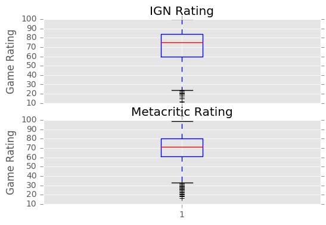

```python
# I found boths of these visualizations to be very useful for understanding the distribution and ratings style of IGN and Metacritic

# Create figure 1, subplot 1
fig2 = plt.figure(2)
plot1= fig2.add_subplot(2,1,1)
plt.title('IGN Rating')
plt.ylabel('Game Rating')
plot1.boxplot(df['IGN_Rating'])

#Create figure 1, subplot 2
plot2 = fig2.add_subplot(2,1,2)
plt.title('Metacritic Rating')
plt.ylabel('Game Rating')
plot2.boxplot(df['Meta_Rating'])

plt.show()
```

## But wait, there's more

I may have been wrong about my overall assumptions regarding the distribution of IGN and Metacritic ratings, but how do they compare on a much smaller sample? Say, the Call of Duty franchise.

Pandas makes this a breeze. Make a new dataframe, selecting the results with 'Call of Duty'. Reset the Indices so matplotlib doesnt crash trying to graph them.

```python
cod = df[df['Game'].str.contains('Call of Duty')]
cod = cod.reset_index()
print(cod)
```

```
    index                                            Game  \
0     244                  Call of Duty 4: Modern Warfare
1     269                  Call of Duty 4: Modern Warfare
2     276                  Call of Duty 4: Modern Warfare
3    1702                                    Call of Duty
4    2689                  Call of Duty: Modern Warfare 3
5    2705                  Call of Duty: Modern Warfare 3
6    2709                  Call of Duty: Modern Warfare 3
7    2711                  Call of Duty: Modern Warfare 3
8    2802                         Call of Duty: Black Ops
9    2807                         Call of Duty: Black Ops
10   2811                         Call of Duty: Black Ops
11   4483                      Call of Duty: Black Ops II
12   4551                            Call of Duty Classic
13   4554                            Call of Duty Classic
```

[output cut: 64 more lines]

Well there's a whole bunch of numbers. Lets run describe() again, then plot our results and see what we can find out.

```
       IGN_Rating  Meta_Rating
count   38.000000    38.000000
mean    81.421053    79.263158
std     13.159380    10.559188
min     40.000000    33.000000
25%     75.000000    74.250000
50%     84.500000    81.000000
75%     92.000000    84.750000
max     95.000000    94.000000
```

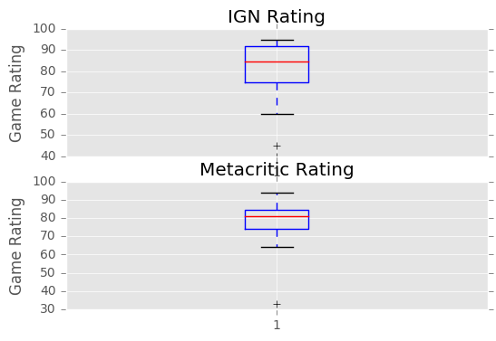

```python
# Create figure 1, subplot 1
fig3 = plt.figure(3)
plot1= fig3.add_subplot(2,1,1)
plt.title('IGN Rating')
plt.ylabel('Game Rating')
plot1.boxplot(cod['IGN_Rating'])

#Create figure 1, subplot 2
plot2 = fig3.add_subplot(2,1,2)
plt.title('Metacritic Rating')
plt.ylabel('Game Rating')
plot2.boxplot(cod['Meta_Rating'])

# describe() decided it wanted to give me statistics on the index column too. We only want the float columns.
print(cod.describe(include=[np.float64]))

plt.show()
```

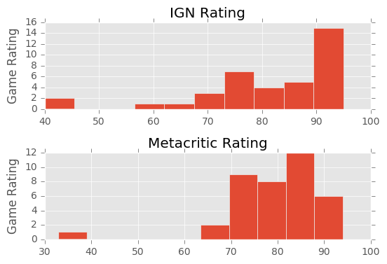

```python
fig4 = plt.figure(4)
plot1 = fig4.add_subplot(2,1,1)
plt.title('IGN Rating')
plt.ylabel('Game Rating')
plot1.hist(cod['IGN_Rating'])

# space out the graphs abit
fig4.subplots_adjust(hspace=.5)

plot2 = fig4.add_subplot(2,1,2)
plt.title('Metacritic Rating')
plt.ylabel('Game Rating')
plot2.hist(cod['Meta_Rating'])

plt.show()
```

### The results

The results for the Call of Duty dataset are a little less clear. The first thing I noticed is that there is a clear outlier in the 30-40 range. Upon furhter inspection, its seems that Call of Duty: Black Ops Declassified for the PSP was very unpopular. Next, the histogram shows that I was at least partially right in that IGN is more likely to give a Call of Duty game a 90+ rating, yet overall they are more inconsistent, particularly with older titles. metacritic has a tighter distribution, yet IGn and Metacritic average out at 81 and 79, respectively.

# In Conclusion

In the end, this was a very interesting foray into Data Science and Analysis. I learned a few things about an interesting topic, and I hope you did as well. I started this not knowling a lick of python, and managed to learn some pretty cool stuff. There are some fascinating libraries such as pandas, pyplot, and beautifulsoup that help you to do some incerdible things. Thank you reading through this, and if you want to contact me, you can find my information on the main page!